# Risk Factor Analysis

## Outcome Variable

**Outcome Variable:** stunted

## Predictor Variables

**Intervention Variable:** vagbrth

**Adjustment Set:**

- arm
- sex
- W_mage
- meducyrs
- feducyrs
- hhwealth_quart
- W_mhtcm
- W_mwtkg
- W_mbmi
- single
- W_nrooms
- brthmon
- W_parity
- impfloor
- delta_W_mage
- delta_meducyrs
- delta_feducyrs
- delta_hhwealth_quart
- delta_W_mhtcm
- delta_W_mwtkg
- delta_W_mbmi
- delta_single
- delta_W_nrooms
- delta_brthmon
- delta_W_parity
- delta_impfloor

## Stratifying Variables

The analysis was stratified on these variable(s):

- agecat
- studyid
- country

## Data Summary

| agecat | studyid | country | vagbrth | stunted | n_cell | n |
| --- | --- | --- | --- | --- | --- | --- |
| Birth | ki1000108-CMC-V-BCS-2002 | INDIA | 0 | 0 | 9 | 92 |
| Birth | ki1000108-CMC-V-BCS-2002 | INDIA | 0 | 1 | 2 | 92 |
| Birth | ki1000108-CMC-V-BCS-2002 | INDIA | 1 | 0 | 66 | 92 |
| Birth | ki1000108-CMC-V-BCS-2002 | INDIA | 1 | 1 | 15 | 92 |
| Birth | ki1000108-IRC | INDIA | 0 | 0 | 58 | 388 |
| Birth | ki1000108-IRC | INDIA | 0 | 1 | 10 | 388 |
| Birth | ki1000108-IRC | INDIA | 1 | 0 | 285 | 388 |
| Birth | ki1000108-IRC | INDIA | 1 | 1 | 35 | 388 |
| Birth | ki1017093b-PROVIDE | BANGLADESH | 0 | 0 | 98 | 539 |
| Birth | ki1017093b-PROVIDE | BANGLADESH | 0 | 1 | 10 | 539 |
| Birth | ki1017093b-PROVIDE | BANGLADESH | 1 | 0 | 393 | 539 |
| Birth | ki1017093b-PROVIDE | BANGLADESH | 1 | 1 | 38 | 539 |
| Birth | ki1017093c-NIH-Crypto | BANGLADESH | 0 | 0 | 160 | 477 |
| Birth | ki1017093c-NIH-Crypto | BANGLADESH | 0 | 1 | 26 | 477 |
| Birth | ki1017093c-NIH-Crypto | BANGLADESH | 1 | 0 | 253 | 477 |
| Birth | ki1017093c-NIH-Crypto | BANGLADESH | 1 | 1 | 38 | 477 |
| Birth | ki1119695-PROBIT | BELARUS | 0 | 0 | 1594 | 13890 |
| Birth | ki1119695-PROBIT | BELARUS | 0 | 1 | 3 | 13890 |
| Birth | ki1119695-PROBIT | BELARUS | 1 | 0 | 12263 | 13890 |
| Birth | ki1119695-PROBIT | BELARUS | 1 | 1 | 30 | 13890 |
| Birth | ki1126311-ZVITAMBO | ZIMBABWE | 0 | 0 | 1076 | 13761 |
| Birth | ki1126311-ZVITAMBO | ZIMBABWE | 0 | 1 | 90 | 13761 |
| Birth | ki1126311-ZVITAMBO | ZIMBABWE | 1 | 0 | 11273 | 13761 |
| Birth | ki1126311-ZVITAMBO | ZIMBABWE | 1 | 1 | 1322 | 13761 |
| Birth | kiGH5241-JiVitA-3 | BANGLADESH | 0 | 0 | 418 | 22418 |
| Birth | kiGH5241-JiVitA-3 | BANGLADESH | 0 | 1 | 121 | 22418 |
| Birth | kiGH5241-JiVitA-3 | BANGLADESH | 1 | 0 | 14626 | 22418 |
| Birth | kiGH5241-JiVitA-3 | BANGLADESH | 1 | 1 | 7253 | 22418 |
| Birth | kiGH5241-JiVitA-4 | BANGLADESH | 0 | 0 | 57 | 2822 |
| Birth | kiGH5241-JiVitA-4 | BANGLADESH | 0 | 1 | 19 | 2822 |

[output cut: 74 more lines]

The following strata were considered:

- agecat: 24 months, studyid: ki1000108-CMC-V-BCS-2002, country: INDIA
- agecat: 24 months, studyid: ki1000108-IRC, country: INDIA
- agecat: 24 months, studyid: ki1017093b-PROVIDE, country: BANGLADESH
- agecat: 24 months, studyid: ki1017093c-NIH-Crypto, country: BANGLADESH
- agecat: 24 months, studyid: ki1066203-TanzaniaChild2, country: TANZANIA, UNITED REPUBLIC OF
- agecat: 24 months, studyid: ki1119695-PROBIT, country: BELARUS
- agecat: 24 months, studyid: ki1126311-ZVITAMBO, country: ZIMBABWE
- agecat: 24 months, studyid: kiGH5241-JiVitA-3, country: BANGLADESH
- agecat: 24 months, studyid: kiGH5241-JiVitA-4, country: BANGLADESH
- agecat: 6 months, studyid: ki1000108-CMC-V-BCS-2002, country: INDIA
- agecat: 6 months, studyid: ki1000108-IRC, country: INDIA
- agecat: 6 months, studyid: ki1017093b-PROVIDE, country: BANGLADESH
- agecat: 6 months, studyid: ki1017093c-NIH-Crypto, country: BANGLADESH
- agecat: 6 months, studyid: ki1066203-TanzaniaChild2, country: TANZANIA, UNITED REPUBLIC OF
- agecat: 6 months, studyid: ki1119695-PROBIT, country: BELARUS
- agecat: 6 months, studyid: ki1126311-ZVITAMBO, country: ZIMBABWE
- agecat: 6 months, studyid: kiGH5241-JiVitA-3, country: BANGLADESH
- agecat: 6 months, studyid: kiGH5241-JiVitA-4, country: BANGLADESH
- agecat: Birth, studyid: ki1000108-CMC-V-BCS-2002, country: INDIA
- agecat: Birth, studyid: ki1000108-IRC, country: INDIA
- agecat: Birth, studyid: ki1017093b-PROVIDE, country: BANGLADESH
- agecat: Birth, studyid: ki1017093c-NIH-Crypto, country: BANGLADESH
- agecat: Birth, studyid: ki1119695-PROBIT, country: BELARUS
- agecat: Birth, studyid: ki1126311-ZVITAMBO, country: ZIMBABWE
- agecat: Birth, studyid: kiGH5241-JiVitA-3, country: BANGLADESH
- agecat: Birth, studyid: kiGH5241-JiVitA-4, country: BANGLADESH

### Dropped Strata

Some strata were dropped due to rare outcomes:

- agecat: Birth, studyid: ki1000108-CMC-V-BCS-2002, country: INDIA
- agecat: Birth, studyid: ki1119695-PROBIT, country: BELARUS
- agecat: 24 months, studyid: ki1066203-TanzaniaChild2, country: TANZANIA, UNITED REPUBLIC OF

## Methods Detail

We’re interested in the causal parameters $E[Y_a]$ for all values of $a \in \mathcal{A}$. These parameters represent the mean outcome if, possibly contrary to fact, we intervened to set all units to have $A=a$. Under the randomization and positivity assumptions, these are identified by the statistical parameters $\psi_a=E_W[E_{Y|A,W}(Y|A=a,W)]$. In addition, we’re interested in the mean of $Y$, $E[Y]$ under no intervention (the observed mean). We will estimate these parameters by using SuperLearner to fit the relevant likelihood factors – $E_{Y|A,W}(Y|A=a,W)$ and $p(A=a|W)$, and then updating our likelihood fit using a joint TMLE.

For unadjusted analyses ($W=\{\}$), initial likelihoods were estimated using Lrnr_glm to estimate the simple $E(Y|A)$ and Lrnr_mean to estimate $p(A)$. For adjusted analyses, a small library containing Lrnr_glmnet, Lrnr_xgboost, and Lrnr_mean was used.

Having estimated these parameters, we will then use the delta method to estimate relative risks and attributable risks relative to a prespecified baseline level of $A$.

# Results Detail

## Results Plots

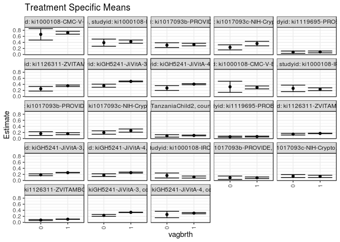

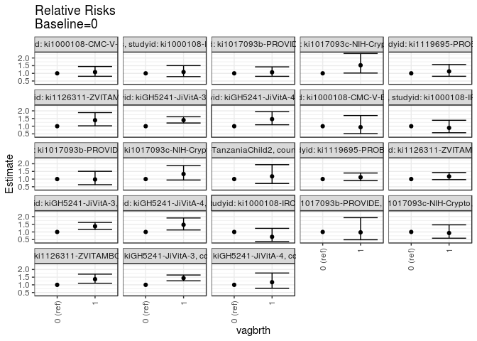

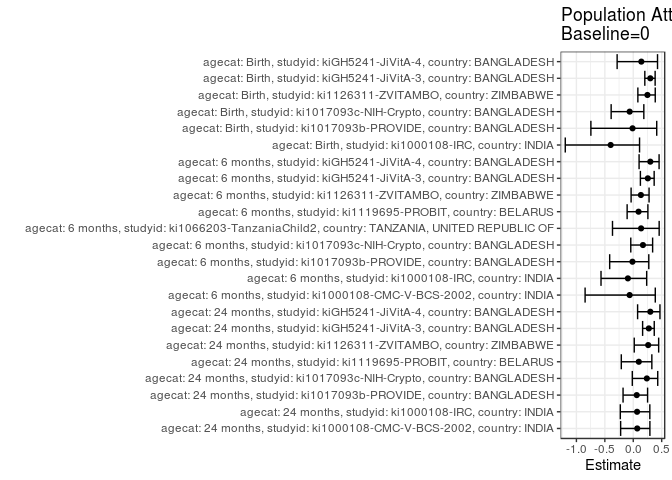

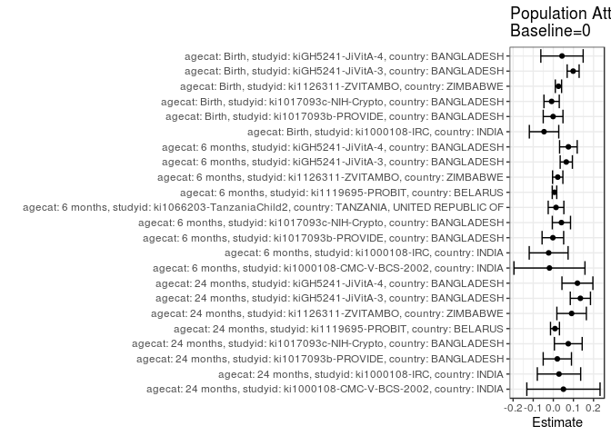

## Results Table

### Parameter: TSM

| agecat | studyid | country | intervention_level | baseline_level | estimate | ci_lower | ci_upper |
| --- | --- | --- | --- | --- | --- | --- | --- |
| Birth | ki1000108-IRC | INDIA | 0 | NA | 0.1620878 | 0.0799613 | 0.2442144 |
| Birth | ki1000108-IRC | INDIA | 1 | NA | 0.1104533 | 0.0761619 | 0.1447446 |
| Birth | ki1017093b-PROVIDE | BANGLADESH | 0 | NA | 0.0901698 | 0.0350485 | 0.1452910 |
| Birth | ki1017093b-PROVIDE | BANGLADESH | 1 | NA | 0.0879027 | 0.0610973 | 0.1147081 |
| Birth | ki1017093c-NIH-Crypto | BANGLADESH | 0 | NA | 0.1426820 | 0.0934856 | 0.1918784 |
| Birth | ki1017093c-NIH-Crypto | BANGLADESH | 1 | NA | 0.1329592 | 0.0942215 | 0.1716970 |
| Birth | ki1126311-ZVITAMBO | ZIMBABWE | 0 | NA | 0.0770417 | 0.0609601 | 0.0931233 |
| Birth | ki1126311-ZVITAMBO | ZIMBABWE | 1 | NA | 0.1053589 | 0.0999919 | 0.1107259 |
| Birth | kiGH5241-JiVitA-3 | BANGLADESH | 0 | NA | 0.2303278 | 0.1999929 | 0.2606627 |
| Birth | kiGH5241-JiVitA-3 | BANGLADESH | 1 | NA | 0.3313044 | 0.3238398 | 0.3387689 |
| Birth | kiGH5241-JiVitA-4 | BANGLADESH | 0 | NA | 0.2605380 | 0.1553377 | 0.3657383 |
| Birth | kiGH5241-JiVitA-4 | BANGLADESH | 1 | NA | 0.3052393 | 0.2847206 | 0.3257580 |
| 6 months | ki1000108-CMC-V-BCS-2002 | INDIA | 0 | NA | 0.3200000 | 0.1368964 | 0.5031036 |
| 6 months | ki1000108-CMC-V-BCS-2002 | INDIA | 1 | NA | 0.2994186 | 0.2509538 | 0.3478835 |
| 6 months | ki1000108-IRC | INDIA | 0 | NA | 0.2688629 | 0.1620712 | 0.3756547 |
| 6 months | ki1000108-IRC | INDIA | 1 | NA | 0.2396232 | 0.1940096 | 0.2852368 |
| 6 months | ki1017093b-PROVIDE | BANGLADESH | 0 | NA | 0.1611960 | 0.1000784 | 0.2223136 |
| 6 months | ki1017093b-PROVIDE | BANGLADESH | 1 | NA | 0.1574975 | 0.1243280 | 0.1906669 |
| 6 months | ki1017093c-NIH-Crypto | BANGLADESH | 0 | NA | 0.1960707 | 0.1398521 | 0.2522893 |
| 6 months | ki1017093c-NIH-Crypto | BANGLADESH | 1 | NA | 0.2606159 | 0.2082548 | 0.3129769 |
| 6 months | ki1066203-TanzaniaChild2 | TANZANIA, UNITED REPUBLIC OF | 0 | NA | 0.0847110 | 0.0439822 | 0.1254399 |
| 6 months | ki1066203-TanzaniaChild2 | TANZANIA, UNITED REPUBLIC OF | 1 | NA | 0.0996922 | 0.0859103 | 0.1134741 |
| 6 months | ki1119695-PROBIT | BELARUS | 0 | NA | 0.0568606 | 0.0387942 | 0.0749271 |
| 6 months | ki1119695-PROBIT | BELARUS | 1 | NA | 0.0635430 | 0.0497462 | 0.0773398 |
| 6 months | ki1126311-ZVITAMBO | ZIMBABWE | 0 | NA | 0.1414345 | 0.1147518 | 0.1681173 |
| 6 months | ki1126311-ZVITAMBO | ZIMBABWE | 1 | NA | 0.1659970 | 0.1577806 | 0.1742134 |
| 6 months | kiGH5241-JiVitA-3 | BANGLADESH | 0 | NA | 0.1871039 | 0.1561371 | 0.2180706 |
| 6 months | kiGH5241-JiVitA-3 | BANGLADESH | 1 | NA | 0.2565282 | 0.2482286 | 0.2648278 |
| 6 months | kiGH5241-JiVitA-4 | BANGLADESH | 0 | NA | 0.1749851 | 0.1300731 | 0.2198971 |
| 6 months | kiGH5241-JiVitA-4 | BANGLADESH | 1 | NA | 0.2570310 | 0.2400258 | 0.2740362 |
| 24 months | ki1000108-CMC-V-BCS-2002 | INDIA | 0 | NA | 0.6666667 | 0.4778144 | 0.8555190 |
| 24 months | ki1000108-CMC-V-BCS-2002 | INDIA | 1 | NA | 0.7204611 | 0.6731791 | 0.7677431 |
| 24 months | ki1000108-IRC | INDIA | 0 | NA | 0.3922993 | 0.2747163 | 0.5098823 |
| 24 months | ki1000108-IRC | INDIA | 1 | NA | 0.4259908 | 0.3733101 | 0.4786716 |
| 24 months | ki1017093b-PROVIDE | BANGLADESH | 0 | NA | 0.3087667 | 0.2293813 | 0.3881521 |
| 24 months | ki1017093b-PROVIDE | BANGLADESH | 1 | NA | 0.3301886 | 0.2867193 | 0.3736579 |
| 24 months | ki1017093c-NIH-Crypto | BANGLADESH | 0 | NA | 0.2371274 | 0.1534836 | 0.3207712 |
| 24 months | ki1017093c-NIH-Crypto | BANGLADESH | 1 | NA | 0.3621167 | 0.2877866 | 0.4364468 |
| 24 months | ki1119695-PROBIT | BELARUS | 0 | NA | 0.0769568 | 0.0388043 | 0.1151093 |
| 24 months | ki1119695-PROBIT | BELARUS | 1 | NA | 0.0867713 | 0.0572065 | 0.1163361 |
| 24 months | ki1126311-ZVITAMBO | ZIMBABWE | 0 | NA | 0.2555151 | 0.1793300 | 0.3317002 |
| 24 months | ki1126311-ZVITAMBO | ZIMBABWE | 1 | NA | 0.3550782 | 0.3308000 | 0.3793564 |
| 24 months | kiGH5241-JiVitA-3 | BANGLADESH | 0 | NA | 0.3566693 | 0.3056406 | 0.4076980 |
| 24 months | kiGH5241-JiVitA-3 | BANGLADESH | 1 | NA | 0.4983272 | 0.4848903 | 0.5117642 |
| 24 months | kiGH5241-JiVitA-4 | BANGLADESH | 0 | NA | 0.2796400 | 0.1992339 | 0.3600461 |
| 24 months | kiGH5241-JiVitA-4 | BANGLADESH | 1 | NA | 0.4088099 | 0.3895563 | 0.4280636 |

### Parameter: E(Y)

| agecat | studyid | country | intervention_level | baseline_level | estimate | ci_lower | ci_upper |
| --- | --- | --- | --- | --- | --- | --- | --- |
| Birth | ki1000108-IRC | INDIA | NA | NA | 0.1159794 | 0.0840777 | 0.1478811 |
| Birth | ki1017093b-PROVIDE | BANGLADESH | NA | NA | 0.0890538 | 0.0649864 | 0.1131212 |
| Birth | ki1017093c-NIH-Crypto | BANGLADESH | NA | NA | 0.1341719 | 0.1035529 | 0.1647909 |
| Birth | ki1126311-ZVITAMBO | ZIMBABWE | NA | NA | 0.1026088 | 0.0975387 | 0.1076790 |
| Birth | kiGH5241-JiVitA-3 | BANGLADESH | NA | NA | 0.3289321 | 0.3215578 | 0.3363064 |
| Birth | kiGH5241-JiVitA-4 | BANGLADESH | NA | NA | 0.3036853 | 0.2836812 | 0.3236894 |
| 6 months | ki1000108-CMC-V-BCS-2002 | INDIA | NA | NA | 0.3008130 | 0.2539566 | 0.3476694 |
| 6 months | ki1000108-IRC | INDIA | NA | NA | 0.2457002 | 0.2038248 | 0.2875757 |
| 6 months | ki1017093b-PROVIDE | BANGLADESH | NA | NA | 0.1589404 | 0.1297581 | 0.1881227 |
| 6 months | ki1017093c-NIH-Crypto | BANGLADESH | NA | NA | 0.2363239 | 0.1973320 | 0.2753157 |
| 6 months | ki1066203-TanzaniaChild2 | TANZANIA, UNITED REPUBLIC OF | NA | NA | 0.0982544 | 0.0852222 | 0.1112865 |
| 6 months | ki1119695-PROBIT | BELARUS | NA | NA | 0.0626864 | 0.0488489 | 0.0765238 |
| 6 months | ki1126311-ZVITAMBO | ZIMBABWE | NA | NA | 0.1633531 | 0.1555398 | 0.1711664 |
| 6 months | kiGH5241-JiVitA-3 | BANGLADESH | NA | NA | 0.2515539 | 0.2434271 | 0.2596807 |
| 6 months | kiGH5241-JiVitA-4 | BANGLADESH | NA | NA | 0.2500000 | 0.2338924 | 0.2661076 |
| 24 months | ki1000108-CMC-V-BCS-2002 | INDIA | NA | NA | 0.7169811 | 0.6710815 | 0.7628807 |
| 24 months | ki1000108-IRC | INDIA | NA | NA | 0.4205379 | 0.3726382 | 0.4684376 |
| 24 months | ki1017093b-PROVIDE | BANGLADESH | NA | NA | 0.3287197 | 0.2903909 | 0.3670485 |
| 24 months | ki1017093c-NIH-Crypto | BANGLADESH | NA | NA | 0.3115385 | 0.2551365 | 0.3679404 |
| 24 months | ki1119695-PROBIT | BELARUS | NA | NA | 0.0852540 | 0.0554439 | 0.1150642 |
| 24 months | ki1126311-ZVITAMBO | ZIMBABWE | NA | NA | 0.3465102 | 0.3233236 | 0.3696967 |
| 24 months | kiGH5241-JiVitA-3 | BANGLADESH | NA | NA | 0.4912628 | 0.4781447 | 0.5043809 |
| 24 months | kiGH5241-JiVitA-4 | BANGLADESH | NA | NA | 0.3995025 | 0.3807924 | 0.4182126 |

### Parameter: RR

| agecat | studyid | country | intervention_level | baseline_level | estimate | ci_lower | ci_upper |
| --- | --- | --- | --- | --- | --- | --- | --- |
| Birth | ki1000108-IRC | INDIA | 0 | 0 | 1.0000000 | 1.0000000 | 1.000000 |
| Birth | ki1000108-IRC | INDIA | 1 | 0 | 0.6814408 | 0.3762243 | 1.234268 |
| Birth | ki1017093b-PROVIDE | BANGLADESH | 0 | 0 | 1.0000000 | 1.0000000 | 1.000000 |
| Birth | ki1017093b-PROVIDE | BANGLADESH | 1 | 0 | 0.9748573 | 0.4921659 | 1.930948 |
| Birth | ki1017093c-NIH-Crypto | BANGLADESH | 0 | 0 | 1.0000000 | 1.0000000 | 1.000000 |
| Birth | ki1017093c-NIH-Crypto | BANGLADESH | 1 | 0 | 0.9318569 | 0.5931697 | 1.463927 |
| Birth | ki1126311-ZVITAMBO | ZIMBABWE | 0 | 0 | 1.0000000 | 1.0000000 | 1.000000 |
| Birth | ki1126311-ZVITAMBO | ZIMBABWE | 1 | 0 | 1.3675558 | 1.1031349 | 1.695358 |
| Birth | kiGH5241-JiVitA-3 | BANGLADESH | 0 | 0 | 1.0000000 | 1.0000000 | 1.000000 |
| Birth | kiGH5241-JiVitA-3 | BANGLADESH | 1 | 0 | 1.4384039 | 1.2605395 | 1.641365 |
| Birth | kiGH5241-JiVitA-4 | BANGLADESH | 0 | 0 | 1.0000000 | 1.0000000 | 1.000000 |
| Birth | kiGH5241-JiVitA-4 | BANGLADESH | 1 | 0 | 1.1715730 | 0.7751656 | 1.770697 |
| 6 months | ki1000108-CMC-V-BCS-2002 | INDIA | 0 | 0 | 1.0000000 | 1.0000000 | 1.000000 |
| 6 months | ki1000108-CMC-V-BCS-2002 | INDIA | 1 | 0 | 0.9356831 | 0.5162674 | 1.695832 |
| 6 months | ki1000108-IRC | INDIA | 0 | 0 | 1.0000000 | 1.0000000 | 1.000000 |
| 6 months | ki1000108-IRC | INDIA | 1 | 0 | 0.8912467 | 0.5736670 | 1.384637 |
| 6 months | ki1017093b-PROVIDE | BANGLADESH | 0 | 0 | 1.0000000 | 1.0000000 | 1.000000 |
| 6 months | ki1017093b-PROVIDE | BANGLADESH | 1 | 0 | 0.9770555 | 0.6335393 | 1.506832 |
| 6 months | ki1017093c-NIH-Crypto | BANGLADESH | 0 | 0 | 1.0000000 | 1.0000000 | 1.000000 |
| 6 months | ki1017093c-NIH-Crypto | BANGLADESH | 1 | 0 | 1.3291932 | 0.9388627 | 1.881803 |
| 6 months | ki1066203-TanzaniaChild2 | TANZANIA, UNITED REPUBLIC OF | 0 | 0 | 1.0000000 | 1.0000000 | 1.000000 |
| 6 months | ki1066203-TanzaniaChild2 | TANZANIA, UNITED REPUBLIC OF | 1 | 0 | 1.1768500 | 0.7140515 | 1.939602 |
| 6 months | ki1119695-PROBIT | BELARUS | 0 | 0 | 1.0000000 | 1.0000000 | 1.000000 |
| 6 months | ki1119695-PROBIT | BELARUS | 1 | 0 | 1.1175216 | 0.8949968 | 1.395373 |
| 6 months | ki1126311-ZVITAMBO | ZIMBABWE | 0 | 0 | 1.0000000 | 1.0000000 | 1.000000 |
| 6 months | ki1126311-ZVITAMBO | ZIMBABWE | 1 | 0 | 1.1736666 | 0.9659498 | 1.426051 |
| 6 months | kiGH5241-JiVitA-3 | BANGLADESH | 0 | 0 | 1.0000000 | 1.0000000 | 1.000000 |
| 6 months | kiGH5241-JiVitA-3 | BANGLADESH | 1 | 0 | 1.3710472 | 1.1599465 | 1.620566 |
| 6 months | kiGH5241-JiVitA-4 | BANGLADESH | 0 | 0 | 1.0000000 | 1.0000000 | 1.000000 |
| 6 months | kiGH5241-JiVitA-4 | BANGLADESH | 1 | 0 | 1.4688738 | 1.1289372 | 1.911170 |
| 24 months | ki1000108-CMC-V-BCS-2002 | INDIA | 0 | 0 | 1.0000000 | 1.0000000 | 1.000000 |
| 24 months | ki1000108-CMC-V-BCS-2002 | INDIA | 1 | 0 | 1.0806916 | 0.8080108 | 1.445395 |
| 24 months | ki1000108-IRC | INDIA | 0 | 0 | 1.0000000 | 1.0000000 | 1.000000 |
| 24 months | ki1000108-IRC | INDIA | 1 | 0 | 1.0858823 | 0.7850518 | 1.501991 |
| 24 months | ki1017093b-PROVIDE | BANGLADESH | 0 | 0 | 1.0000000 | 1.0000000 | 1.000000 |
| 24 months | ki1017093b-PROVIDE | BANGLADESH | 1 | 0 | 1.0693788 | 0.8041055 | 1.422165 |
| 24 months | ki1017093c-NIH-Crypto | BANGLADESH | 0 | 0 | 1.0000000 | 1.0000000 | 1.000000 |
| 24 months | ki1017093c-NIH-Crypto | BANGLADESH | 1 | 0 | 1.5270977 | 1.0186055 | 2.289432 |
| 24 months | ki1119695-PROBIT | BELARUS | 0 | 0 | 1.0000000 | 1.0000000 | 1.000000 |
| 24 months | ki1119695-PROBIT | BELARUS | 1 | 0 | 1.1275331 | 0.8075042 | 1.574395 |
| 24 months | ki1126311-ZVITAMBO | ZIMBABWE | 0 | 0 | 1.0000000 | 1.0000000 | 1.000000 |
| 24 months | ki1126311-ZVITAMBO | ZIMBABWE | 1 | 0 | 1.3896562 | 1.0240409 | 1.885808 |
| 24 months | kiGH5241-JiVitA-3 | BANGLADESH | 0 | 0 | 1.0000000 | 1.0000000 | 1.000000 |
| 24 months | kiGH5241-JiVitA-3 | BANGLADESH | 1 | 0 | 1.3971688 | 1.2089007 | 1.614757 |
| 24 months | kiGH5241-JiVitA-4 | BANGLADESH | 0 | 0 | 1.0000000 | 1.0000000 | 1.000000 |
| 24 months | kiGH5241-JiVitA-4 | BANGLADESH | 1 | 0 | 1.4619151 | 1.0932630 | 1.954878 |

### Parameter: PAR

| agecat | studyid | country | intervention_level | baseline_level | estimate | ci_lower | ci_upper |
| --- | --- | --- | --- | --- | --- | --- | --- |
| Birth | ki1000108-IRC | INDIA | 0 | NA | -0.0461085 | -0.1192682 | 0.0270513 |
| Birth | ki1017093b-PROVIDE | BANGLADESH | 0 | NA | -0.0011160 | -0.0502210 | 0.0479891 |
| Birth | ki1017093c-NIH-Crypto | BANGLADESH | 0 | NA | -0.0085101 | -0.0465858 | 0.0295656 |
| Birth | ki1126311-ZVITAMBO | ZIMBABWE | 0 | NA | 0.0255671 | 0.0099500 | 0.0411842 |
| Birth | kiGH5241-JiVitA-3 | BANGLADESH | 0 | NA | 0.0986043 | 0.0688350 | 0.1283737 |
| Birth | kiGH5241-JiVitA-4 | BANGLADESH | 0 | NA | 0.0431473 | -0.0620907 | 0.1483853 |
| 6 months | ki1000108-CMC-V-BCS-2002 | INDIA | 0 | NA | -0.0191870 | -0.1957642 | 0.1573902 |
| 6 months | ki1000108-IRC | INDIA | 0 | NA | -0.0231627 | -0.1198019 | 0.0734765 |
| 6 months | ki1017093b-PROVIDE | BANGLADESH | 0 | NA | -0.0022556 | -0.0559216 | 0.0514104 |
| 6 months | ki1017093c-NIH-Crypto | BANGLADESH | 0 | NA | 0.0402531 | -0.0050355 | 0.0855418 |
| 6 months | ki1066203-TanzaniaChild2 | TANZANIA, UNITED REPUBLIC OF | 0 | NA | 0.0135433 | -0.0253974 | 0.0524840 |
| 6 months | ki1119695-PROBIT | BELARUS | 0 | NA | 0.0058257 | -0.0054377 | 0.0170891 |
| 6 months | ki1126311-ZVITAMBO | ZIMBABWE | 0 | NA | 0.0219186 | -0.0037307 | 0.0475679 |
| 6 months | kiGH5241-JiVitA-3 | BANGLADESH | 0 | NA | 0.0644500 | 0.0340673 | 0.0948328 |
| 6 months | kiGH5241-JiVitA-4 | BANGLADESH | 0 | NA | 0.0750149 | 0.0312155 | 0.1188143 |
| 24 months | ki1000108-CMC-V-BCS-2002 | INDIA | 0 | NA | 0.0503145 | -0.1317778 | 0.2324068 |
| 24 months | ki1000108-IRC | INDIA | 0 | NA | 0.0282386 | -0.0795450 | 0.1360222 |
| 24 months | ki1017093b-PROVIDE | BANGLADESH | 0 | NA | 0.0199530 | -0.0503578 | 0.0902639 |
| 24 months | ki1017093c-NIH-Crypto | BANGLADESH | 0 | NA | 0.0744111 | 0.0053756 | 0.1434465 |
| 24 months | ki1119695-PROBIT | BELARUS | 0 | NA | 0.0082972 | -0.0139326 | 0.0305271 |
| 24 months | ki1126311-ZVITAMBO | ZIMBABWE | 0 | NA | 0.0909951 | 0.0176652 | 0.1643249 |
| 24 months | kiGH5241-JiVitA-3 | BANGLADESH | 0 | NA | 0.1345935 | 0.0843709 | 0.1848161 |
| 24 months | kiGH5241-JiVitA-4 | BANGLADESH | 0 | NA | 0.1198625 | 0.0428998 | 0.1968252 |

### Parameter: PAF

| agecat | studyid | country | intervention_level | baseline_level | estimate | ci_lower | ci_upper |
| --- | --- | --- | --- | --- | --- | --- | --- |
| Birth | ki1000108-IRC | INDIA | 0 | NA | -0.3975574 | -1.1958855 | 0.1105335 |
| Birth | ki1017093b-PROVIDE | BANGLADESH | 0 | NA | -0.0125314 | -0.7453947 | 0.4126144 |
| Birth | ki1017093c-NIH-Crypto | BANGLADESH | 0 | NA | -0.0634269 | -0.3888946 | 0.1857721 |
| Birth | ki1126311-ZVITAMBO | ZIMBABWE | 0 | NA | 0.2491706 | 0.0808827 | 0.3866454 |
| Birth | kiGH5241-JiVitA-3 | BANGLADESH | 0 | NA | 0.2997711 | 0.2032304 | 0.3846144 |
| Birth | kiGH5241-JiVitA-4 | BANGLADESH | 0 | NA | 0.1420790 | -0.2837317 | 0.4266493 |
| 6 months | ki1000108-CMC-V-BCS-2002 | INDIA | 0 | NA | -0.0637838 | -0.8471227 | 0.3873521 |
| 6 months | ki1000108-IRC | INDIA | 0 | NA | -0.0942722 | -0.5671525 | 0.2359190 |
| 6 months | ki1017093b-PROVIDE | BANGLADESH | 0 | NA | -0.0141917 | -0.4148488 | 0.2730072 |
| 6 months | ki1017093c-NIH-Crypto | BANGLADESH | 0 | NA | 0.1703304 | -0.0437204 | 0.3404828 |
| 6 months | ki1066203-TanzaniaChild2 | TANZANIA, UNITED REPUBLIC OF | 0 | NA | 0.1378395 | -0.3651878 | 0.4555176 |
| 6 months | ki1119695-PROBIT | BELARUS | 0 | NA | 0.0929345 | -0.1078420 | 0.2573239 |
| 6 months | ki1126311-ZVITAMBO | ZIMBABWE | 0 | NA | 0.1341791 | -0.0380008 | 0.2777984 |
| 6 months | kiGH5241-JiVitA-3 | BANGLADESH | 0 | NA | 0.2562077 | 0.1253304 | 0.3675017 |
| 6 months | kiGH5241-JiVitA-4 | BANGLADESH | 0 | NA | 0.3000597 | 0.1024485 | 0.4541635 |
| 24 months | ki1000108-CMC-V-BCS-2002 | INDIA | 0 | NA | 0.0701754 | -0.2220596 | 0.2925274 |
| 24 months | ki1000108-IRC | INDIA | 0 | NA | 0.0671488 | -0.2278848 | 0.2912923 |
| 24 months | ki1017093b-PROVIDE | BANGLADESH | 0 | NA | 0.0606992 | -0.1794704 | 0.2519643 |
| 24 months | ki1017093c-NIH-Crypto | BANGLADESH | 0 | NA | 0.2388503 | -0.0169528 | 0.4303090 |
| 24 months | ki1119695-PROBIT | BELARUS | 0 | NA | 0.0973238 | -0.2104188 | 0.3268245 |
| 24 months | ki1126311-ZVITAMBO | ZIMBABWE | 0 | NA | 0.2626043 | 0.0172779 | 0.4466875 |
| 24 months | kiGH5241-JiVitA-3 | BANGLADESH | 0 | NA | 0.2739745 | 0.1644723 | 0.3691257 |
| 24 months | kiGH5241-JiVitA-4 | BANGLADESH | 0 | NA | 0.3000293 | 0.0763618 | 0.4695337 |